# Part_4_Anomaly_Detection

Mary_Njuguna

2022-06-10

You are a Data analyst at Carrefour Kenya and are currently undertaking a project that will inform the marketing department on the most relevant marketing strategies that will result in the highest no. of sales (total price including tax). Your project has been divided into four parts where you’ll explore a recent marketing dataset by performing various unsupervised learning techniques and later providing recommendations based on your insights.

Part 4: Anomaly Detection

You have also been requested to check whether there are any anomalies in the given sales dataset. The objective of this task being fraud detection.

### Loading The Libraries

```r
library(ggplot2)
library(tidyverse)
library(dplyr)
library(ggpubr)
library(anomalize)
library(psych)
library(tibbletime)
```

### loading the data

```r
sales_df<- read.csv("http://bit.ly/CarreFourSalesDataset")
```

# Previewing the data

```r
#Viewing the head of the data
head(sales_df)
```

```
##        Date    Sales
## 1  1/5/2019 548.9715
## 2  3/8/2019  80.2200
## 3  3/3/2019 340.5255
## 4 1/27/2019 489.0480
## 5  2/8/2019 634.3785
## 6 3/25/2019 627.6165
```

```r
#Viewing the bottom part of the dataset
tail(sales_df)
```

```
##           Date     Sales
## 995  2/18/2019   63.9975
## 996  1/29/2019   42.3675
## 997   3/2/2019 1022.4900
## 998   2/9/2019   33.4320
## 999  2/22/2019   69.1110
## 1000 2/18/2019  649.2990
```

```r
#printing the columns and rows
dim(sales_df)
```

```
## [1] 1000    2
```

The dataset has 1000 rows and 2 columns

```r
#Checking if the columns are correctly named
colnames(sales_df)
```

```
## [1] "Date"  "Sales"
```

The columns are Date and Sales

```r
#dataset type
class(sales_df)
```

```
## [1] "data.frame"
```

```r
#Checking the dimension of the data
dim(sales_df)
```

```
## [1] 1000    2
```

```r
# printing the structure of the dataset
glimpse(sales_df)
```

```
## Rows: 1,000
## Columns: 2
## $ Date  <chr> "1/5/2019", "3/8/2019", "3/3/2019", "1/27/2019", "2/8/2019", "3/…
## $ Sales <dbl> 548.9715, 80.2200, 340.5255, 489.0480, 634.3785, 627.6165, 433.6…
```

## Data Validation

```r
library(timetk)
#sales_df$Date <- as.Date(sales_df$Date, formart= "%m,%d,%y")
#sales_df$Date <- as.POSIXct(sales_df$Date)
sales_df$Date <- as.POSIXct( sales_df$Date, format="%m/%d/%y" )
sales_df$Date<- sort(sales_df$Date,decreasing = FALSE)
head( sales_df)
```

```
##         Date    Sales
## 1 2020-01-01 548.9715
## 2 2020-01-01  80.2200
## 3 2020-01-01 340.5255
## 4 2020-01-01 489.0480
## 5 2020-01-01 634.3785
## 6 2020-01-01 627.6165
```

# Cleaning the Data

## Completeness

```r
#Checking the total null values
sum(is.na(sales_df))
```

```
## [1] 0
```

## Consistency

```r
#Checking for duplicates
anyDuplicated(sales_df)
```

```
## [1] 0
```

```r
# Selecting Numeric columns
sales_df_num<- select_if(sales_df, is.numeric)
colnames(sales_df_num)
```

```
## [1] "Sales"
```

## Outliers

```r
#Function to calculate the percentage of outliers in each column
outlier_vals<- function(x){
  out<- boxplot.stats(x)$out
  return((length(out)/1000)*100)
}
#Evaluating outliers per column
sapply(sales_df_num,outlier_vals)
```

```
## Sales
##   0.9
```

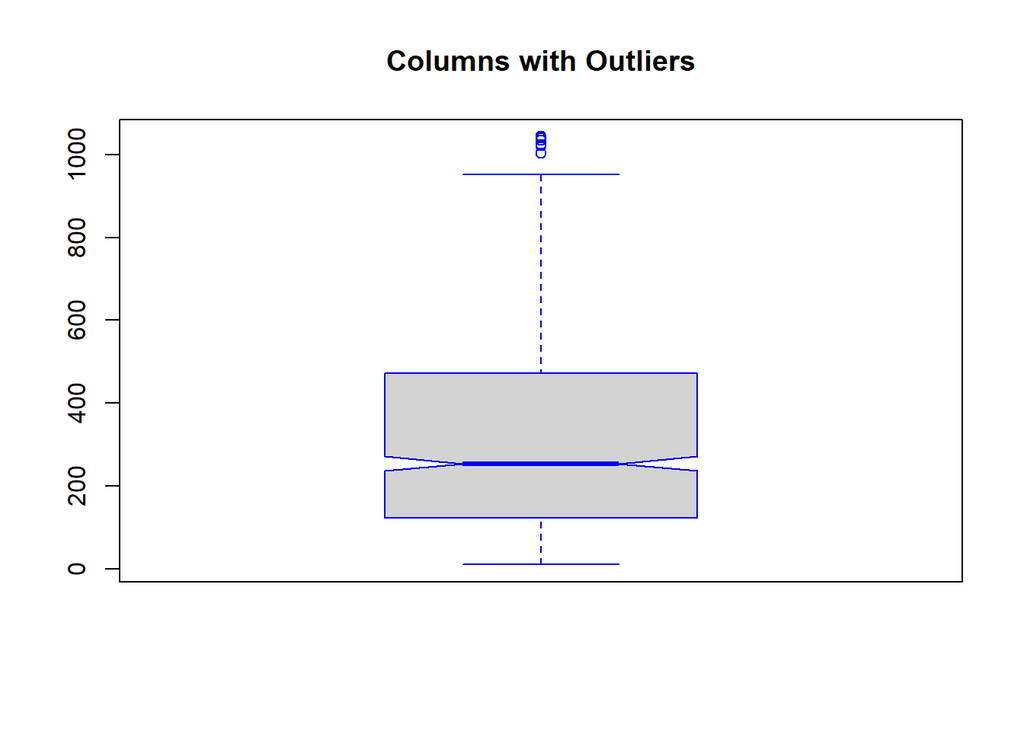

```r
#plotting to visualize the outliers
boxplot(sales_df_num$Sales ,
        main="Columns with Outliers",names = c("Sales "),border = "Blue",notch = TRUE)
```

# Univariate Analysis

## Calculating Descriptive statistics using describe()

describe() computes descriptive statistic for numerical data which helps to determine the distribution of numerical variables.

```r
describe(sales_df_num)
```

```
##       vars    n   mean     sd median trimmed    mad   min     max   range skew
## Sales    1 1000 322.97 245.89 253.85  293.91 233.78 10.68 1042.65 1031.97 0.89
##       kurtosis   se
## Sales    -0.09 7.78
```

## Plotting histogram for sales

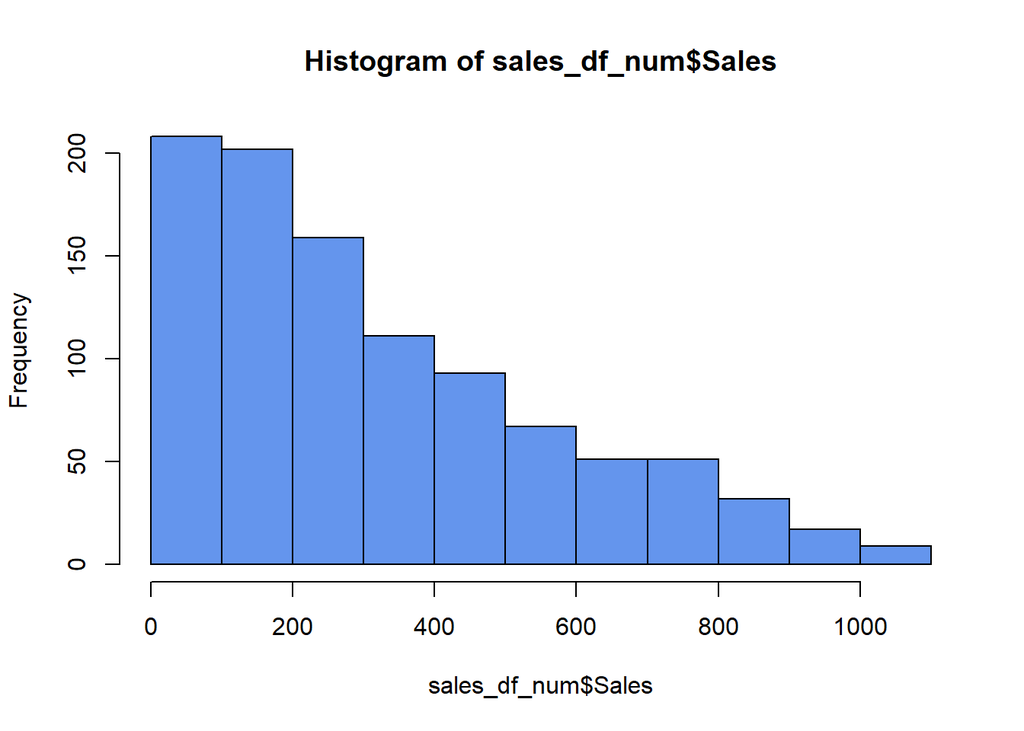

```r
hist(sales_df_num$Sales, col = "cornflowerblue")
```

# Anomaly Detection

```r
library(tibble)
library(tibbletime)
sales_df <- as_tibble(sales_df)
```

```r
head(sales_df)
```

```
## # A tibble: 6 × 2
##   Date                Sales
##   <dttm>              <dbl>
## 1 2020-01-01 00:00:00 549.
## 2 2020-01-01 00:00:00  80.2
## 3 2020-01-01 00:00:00 341.
## 4 2020-01-01 00:00:00 489.
## 5 2020-01-01 00:00:00 634.
## 6 2020-01-01 00:00:00 628.
```

```
## Converting from tbl_df to tbl_time.
## Auto-index message: index = Date
```

```
## frequency = 11 seconds
```

```
## trend = 11 seconds
```

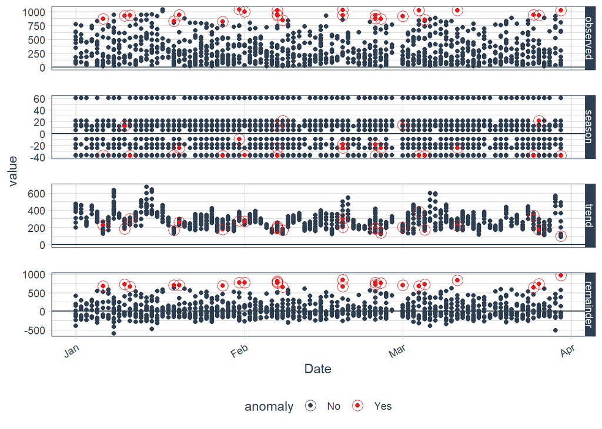

```r
sales_df %>%
time_decompose(Sales, method = "stl", frequency = "auto", trend = "auto") %>%
anomalize(remainder, method = "gesd", alpha = 0.1, max_anoms = 0.5) %>%
plot_anomaly_decomposition()
```

Observation: Red dots indicates the presence of anomalies

```r
#Checking the exact columns with anomalies
anoms = sales_df %>%
time_decompose(Sales, method = "stl", frequency = "auto", trend = "auto") %>%
anomalize(remainder, method = "gesd", alpha = 0.1, max_anoms = 0.5) %>%
time_recompose() %>%
filter(anomaly == 'Yes')
```

```
## Converting from tbl_df to tbl_time.
## Auto-index message: index = Date
```

```
## frequency = 11 seconds
```

```
## trend = 11 seconds
```

```r
anoms
```

```
## # A time tibble: 24 × 10
## # Index: Date
##    Date                observed season trend remainder remainder_l1 remainder_l2
##    <dttm>                 <dbl>  <dbl> <dbl>     <dbl>        <dbl>        <dbl>
##  1 2020-01-06 00:00:00     868. -37.1   223.      682.        -670.         639.
##  2 2020-01-10 00:00:00     923.  12.4   181.      729.        -670.         639.
##  3 2020-01-11 00:00:00     931. -38.0   300.      669.        -670.         639.
##  4 2020-01-19 00:00:00     830. -37.1   168.      699.        -670.         639.
##  5 2020-01-20 00:00:00     942. -25.2   261.      707.        -670.         639.
##  6 2020-01-28 00:00:00     820. -38.0   174.      684.        -670.         639.
##  7 2020-01-31 00:00:00    1043.  -9.34  276.      776.        -670.         639.
##  8 2020-02-01 00:00:00    1002. -37.1   269.      771.        -670.         639.
##  9 2020-02-07 00:00:00    1021.  12.5   197.      811.        -670.         639.
## 10 2020-02-07 00:00:00     952. -25.2   186.      791.        -670.         639.
## # … with 14 more rows, and 3 more variables: anomaly <chr>,
## #   recomposed_l1 <dbl>, recomposed_l2 <dbl>
```

Further investigations should be done in order to determine the cause of anomalies.